# EEW Congressional Report Card

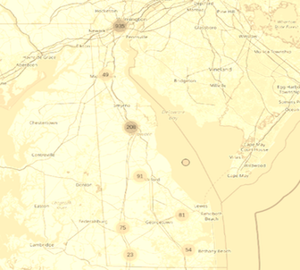

Delaware at large

Seat held by Lisa Rochester since 2017

Report Generated 9 September 2020

Map above shows congressional district with clusters of regulated facilities

The [Environmental Enforcement Watch](https://www.environmentalenforcementwatch.org/) (EEW), a project of [EDGI](https://envirodatagov.org/), produced this report using data from the EPA. It provides information about pollution violations and the EPA’s efforts to control pollution. Congress has the power to strengthen and oversee how well EPA protects us from pollution.

[figure not shown]

[figure not shown]

##### DRAFT not for circulation

# Why and What

## Why

It is Congress’s job to oversee how the laws it passes are implemented by agencies like the Environmental Protection Agency (EPA). Congress has charged the EPA with enforcing most of the laws that protect environmental health by controlling the release of pollution and hazardous materials into the air, water and land. Without effective enforcement, **these laws are meaningless**. Congress can strengthen EPA enforcement by increasing resources to the EPA, passing more effective laws, requiring better data collection, and general oversight. In the **House of Representatives**, the **Energy and Commerce Committee** is the main committee that oversees the EPA. In the **Senate**, the **Environment and Public Works Committee** is the main committee that oversees the EPA.

## What - the Data in this report

While ECHO remains the only publicly available and comprehensive source for environmental compliance data, it is known to be extremely unreliable. According to former EPA Administrator Cynthia Giles, states often report less than 5% of violations under the regulations controlling clean air and hazardous waste, which means that ECHO data may exclude more than 95% of such violations. Therefore, other than the Clean Water Act, for which violations are reported through an automated system, violation data should not be considered accurate. It is important to note that states which might have the most violations may actually be the most responsible in terms of their reporting to EPA. Below is a color code of reliability for each data type presented in this report:

| Metric | Color | Why |
| --- | --- | --- |
| CWA Inspections and Violations; GHG Emissions | Green | Automatic monitoring and Reporting |
| CAA Inspections, RCRA Inspections; CAA, CWA and RCRA Enforcement Actions and Penalities | Yellow | Problems of pass through of data from state to EPA |
| CAA Violations, RCRA violations | Red | Problems of self-reporting and pass through of data from state to EPA |

### See part 2 of [this report](http://eelp.law.harvard.edu/wp-content/uploads/Cynthia-Giles-Part-2-FINAL.pdf) for more information about lack of reporting

##### DRAFT not for circulation

# Highlights for Delaware at large

## Comparing the first 3 years of the Obama administration to the first 3 years of the Trump administration, there has been -35.57% change in inspections, a -47.19% change in enforcement fines, and a 0% change in enforcement actions.

## Under the Clean Water Act, the only well-reported regulation in this report, 16 facilities, representing 20.51% of all regulated facilities in DE, were in violation for at least 25% of the last 3 years.

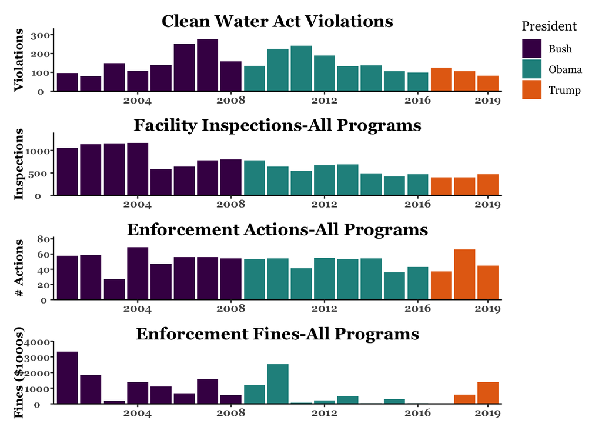

##### DRAFT not for circulation

# Delaware in Comparison

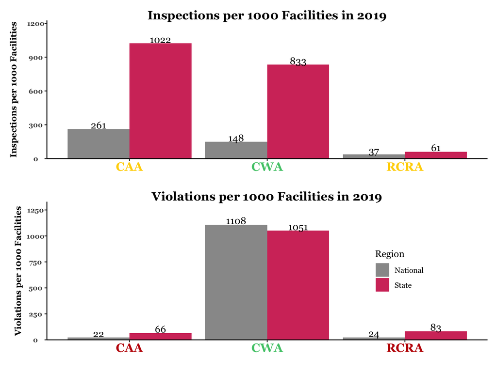

### See color-coded table on page 1 for data reliability color codes, visualized here as x-axis labels and on subsequent pages as chart titles

##### DRAFT not for circulation

# Clean Air Act

## There are 318 CAA facilities

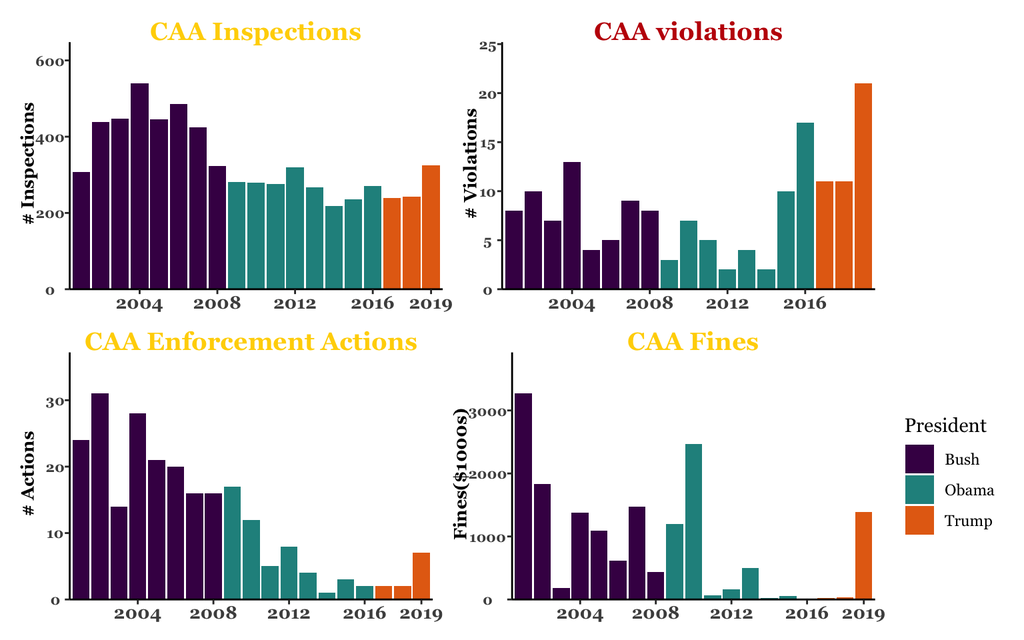

##### DRAFT not for circulation

# Clean Water Act

The Clean Water Act is a series of regulations that govern discharges of pollutants and regulates water quality standards for waters of the United States. The CWA established the National Pollutant Discharge Elimination System (NPDES) which permits discharges of pollutants [EPA](https://www.epa.gov/laws-regulations/summary-clean-water-act). Unlike the CAA, CWA violations are reported automatically through the National Pollutant Discharge Elimination System (NPDES), so violations are recorded independently of facility inspections. CWA inspections often occur in response to recorded violations. [More info on CWA](https://docs.google.com/presentation/d/1g6ZN3B5jvs3F1VAigiUtNNezjXdJnzuELfo9Deo9Y2w/edit?usp=sharing)

## There are 78 CWA facilities

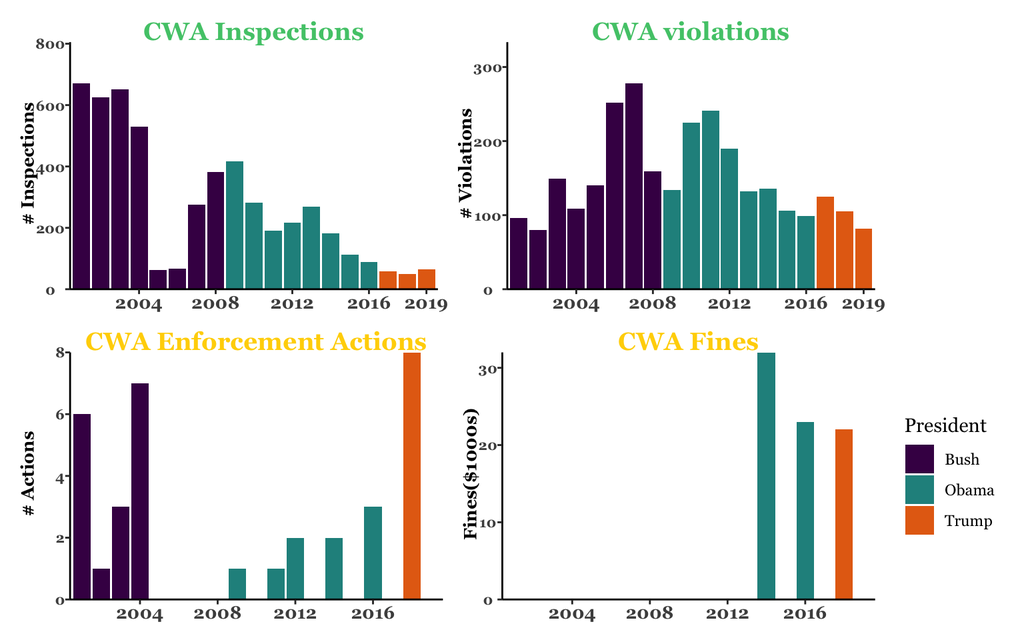

##### DRAFT not for circulation

# Resource Conservation and Recovery Act

The Resource Conservation and Recovery Act (RCRA) gives EPA the authority to control hazardous waste from the “cradle-to-grave”, regulating the generation, transportation, treatment, storage, and disposal of hazardous waste. Although facilities self-report under RCRA, like the CAA, violations are most often found after an inspection, and a reduction in violations might mean a reduction in inspections. [EPA](https://www.epa.gov/laws-regulations/summary-resource-conservation-and-recovery-act) [More info on RCRA](https://docs.google.com/presentation/d/1lV9b_vkcfCbTz8uss1XjXLHy2svpi2tmizb6et1Wfkc/edit?usp=sharing)

## There are 1338 RCRA facilities

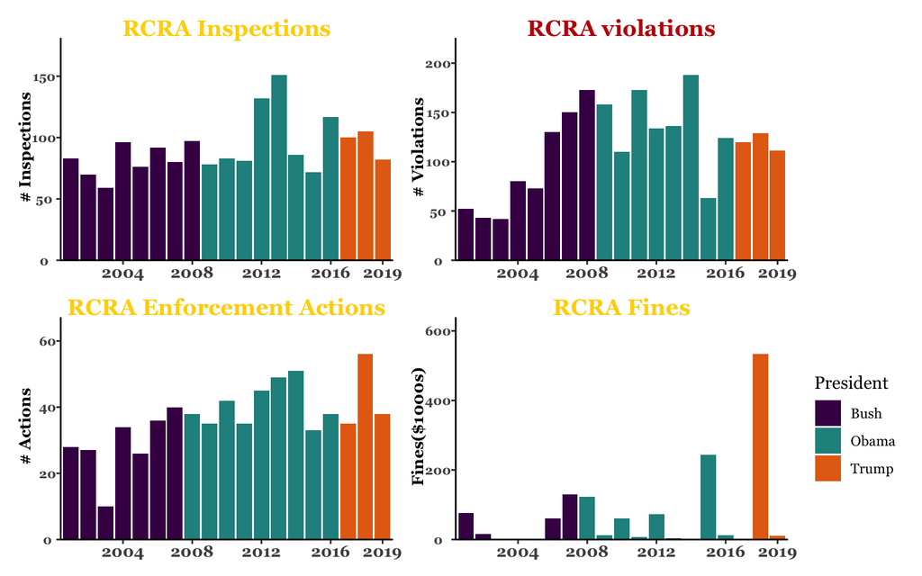

##### DRAFT not for circulation

# Legislator Information

## Lisa Rochester

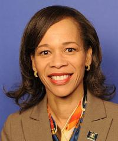

## In office since January 3rd, 2017

## Relevant Committee Membership: [Energy and Commerce Committee](https://energycommerce.house.gov/)

### [House Energy and Commerce Committee](https://energycommerce.house.gov/about-ec)

This Committee is the oldest house Committee with the broadest jurisdiction of aOR authorizing committee. The Committee oversees the EPA, and legislates on issues like environmental protection, clean air, climate change, safe drinking water, toxic chemicals and hazardous waste, and nuclear facilities. Currently, the Committee includes 55 members – 24 Republicans and 31 Democrats. The subcommittees of primary interest to these reports are Environment & Climate Change and Oversight & Investigations.

### Relevant Subcommittees:

1. Energy
2. Environment and Climate Change
3. Health

##### DRAFT not for circulation

# Data Limitations

### Disclaimer

On March 26, 2020, the US EPA released [a policy memo](https://www.epa.gov/sites/production/files/2020-03/documents/oecamemooncovid19implications.pdf) suspending pollution monitoring requirements for industries that claim to have been impacted by COVID-19. Since then, as part of EDGI’s ongoing Environmental Enforcement Watch (EEW) project, we have conducted original data science research using EPA’s Enforcement and Compliance History Online ECHO database to investigate the effects of this policy on facility reporting of environmental data and compliance with environmental protection laws. Results show that, despite relatively few facilities claiming the COVID exemption, a much larger proportion of facilities are still failing to report. While both industry non-compliance and EPA non-enforcement reflect longer-term trends (as much as 70% of facilities were already in non-compliance with the nation’s environmental laws for certain regulatory programs pre-COVID, [Giles 2020](http://eelp.law.harvard.edu/wp-content/uploads/Cynthia-Giles-Part-2-FINAL.pdf)), we have decided to exclude 2020 data from this analysis due to EPA’s COVID-19 policy. This decision serves to provide the fairest and most accurate picture of enforcement and compliance trends, and to avoid skewing and misrepresenting the data. .

##### DRAFT not for circulation

# About the Authors

### About EEW and this Project

Environmental Enforcement Watch (EEW) is a collaborative project across EDGI working groups. The EEW project builds on EDGI’s 2019 [Sheep in the Closet Report](https://envirodatagov.org/publication/a-sheep-in-the-closet-the-erosion-of-enforcement-at-the-epa/) that documents large declines in EPA enforcement of environmental laws. This project and others used data from EPA’s [ECHO](https://echo.epa.gov/) database, revealing how useful ECHO could be for communities to track pollution and EPA responses in their areas. However, they also revealed the inaccessibility of ECHO for non-specialists, along with maOR omissions, errors, and confusions present in the data itself.

A key goal of EEW is to highlight gaps and inadequacies in the enforcement of environmental laws, demonstrating EPA’s failure to fulfill its congressionally mandated duty. To help bring awareness and action to the state of environmental non-compliance across the US, we are using Jupyter Notebooks that utilize ECHO data to present these congressional report cards for the 75 Senators and House Representatives that sit on the House Energy & Commerce Committee and the Senate Environment & Public Works Committee. By providing a novel and poignant look at the chronic state of non-compliance in their states and districts, we hope to provide these key representatives with the information and pressure they need to hold the EPA accountable.

### About EDGI

EDGI is an international network of over 175 members from more than 80 different academic institutions and non-profits, comprised foremost by grassroots volunteer efforts. Since 2016, EDGI has served as a preeminent watchdog group for federal environmental data, generating international effort to duplicate and monitor repositories of public data that are vital to environmental health research and knowledge. EDGI’s work has been widely acknowledged, leading to EDGI testifying before Congress on declines in EPA enforcement, and hundreds of mentions in leading national and international media such as *The New York Times*,*The Washington Post*, Vice News, and CNN. For more about our work, read our [2019 Annual Report](https://envirodatagov.org/publication/edgi-annual-report-2019/)and [2020 Annual Report](https://envirodatagov.org/publication/edgi-annual-report-2020/).

#### [Contact Us](https://www.environmentalenforcementwatch.org/contact/)

[figure not shown]

[figure not shown]